# BTS 510 Lab 7

```r
set.seed(12345)
library(tidyverse)
library(Stat2Data)
theme_set(theme_classic(base_size = 16))
```

## 1 Learning objectives

- **Add predictors** to a linear regression model
- Interpret **partial regression coefficients**
- **Re-code predictors** to answer your research questions
- **Compare** different models using $R^2_{change}$

## 2 Data

- `ICU` data from the **Stat2Data** package
  - `ID`: Patient ID code
  - `Survive`: 1 = patient survived to discharge or 0 = patient died
  - `Age`: Age (in years)
  - `AgeGroup`: 1 = young (under 50), 2 = middle (50-69), 3 = old (70+)
  - `Sex`: 1 = female or 0 = male
  - `Infection`: 1 = infection suspected or 0 = no infection
  - `SysBP`: Systolic blood pressure (in mm of Hg)
  - `Pulse`: Heart rate (beats per minute)
  - `Emergency`: 1 = emergency admission or 0 = elective admission

```r
library(Stat2Data)
data(ICU)
```

## 3 Research question

**How do infection status (`Infection`) and admission type (`Emergency`) predict blood pressure?**

## 4 Tasks

1. Conduct **three linear regression models** to address the above research questions.
- Model 1: Infection status predicts blood pressure
- Model 2: Admission type predicts blood pressure
- Model 3: Infection status *and* admission type predict blood pressure

```r
m1 <- lm(data = ICU, SysBP ~ Infection)
m2 <- lm(data = ICU, SysBP ~ Emergency)
m3 <- lm(data = ICU, SysBP ~ Infection + Emergency)
```

2. **Which is the best model?**
- Use the $F$-test for $R^2_{change}$ and the AIC values to help you decide. Report the tests and values that you used to decide this.

```r
anova(m1, m2)
```

```
Analysis of Variance Table

Model 1: SysBP ~ Infection
Model 2: SysBP ~ Emergency
  Res.Df    RSS Df Sum of Sq F Pr(>F)
1    198 204796
2    198 208758  0   -3961.4
```

```r
anova(m1, m3)
```

```
Analysis of Variance Table

Model 1: SysBP ~ Infection
Model 2: SysBP ~ Infection + Emergency
  Res.Df    RSS Df Sum of Sq      F  Pr(>F)
1    198 204796
2    197 200057  1    4739.2 4.6668 0.03196 *
---
Signif. codes:  0 '***' 0.001 '**' 0.01 '*' 0.05 '.' 0.1 ' ' 1
```

```r
anova(m2, m3)
```

```
Analysis of Variance Table

Model 1: SysBP ~ Emergency
Model 2: SysBP ~ Infection + Emergency
  Res.Df    RSS Df Sum of Sq      F   Pr(>F)
1    198 208758
2    197 200057  1    8700.7 8.5677 0.003824 **
---
Signif. codes:  0 '***' 0.001 '**' 0.01 '*' 0.05 '.' 0.1 ' ' 1
```

- Note: Cannot use this to compare models with same number of predictors because degrees of freedom is the difference in number of predictors
  - Comparison of `m1` and `m2` is useless
- Can compare `m3` (two predictors) to each of the 1 predictor models
  - `m3` is better than `m1`, F(1, 197) = 4.6668, p<.05
  - `m3` is better than `m2`, F(1, 197) = 8.5677, p<.01
  - Basically, both predictors are better than either one alone

```r
AIC(m1)
```

```
[1] 1959.866
```

```r
AIC(m2)
```

```
[1] 1963.698
```

```r
AIC(m3)
```

```
[1] 1957.184
```

- Lower is better for AIC and BIC
  - `m3` has the lowest AIC
3. Report the results of the **best** model, including:
- Intercept value, test statistic, $p$-value, interpretation (in words)
- Slope value(s), test statistic(s), $p$-value(s), interpretation(s) (in words)
- $R^2$ value, test statistic, $p$-value, interpretation (in words)

```r
summary(m3)
```

```
Call:
lm(formula = SysBP ~ Infection + Emergency, data = ICU)

Residuals:
    Min      1Q  Median      3Q     Max
-85.455 -18.694  -1.231  18.657 120.992

Coefficients:
            Estimate Std. Error t value Pr(>|t|)
(Intercept)  146.194      4.569  31.995  < 2e-16 ***
Infection    -13.553      4.630  -2.927  0.00382 **
Emergency    -11.186      5.178  -2.160  0.03196 *
---
Signif. codes:  0 '***' 0.001 '**' 0.01 '*' 0.05 '.' 0.1 ' ' 1

Residual standard error: 31.87 on 197 degrees of freedom
Multiple R-squared:  0.07416,   Adjusted R-squared:  0.06476
F-statistic:  7.89 on 2 and 197 DF,  p-value: 0.0005054
```

- Intercept
  - $b_0$ = 146.194, t(197) = 31.995, p<.0001
  - The predicted blood pressure for a person without an infection (`Infection` = 0) and without an emergency admission (`Emergency` = 0) is 146.194.
- `Infection` effect
  - $b_1$ = -13.553, t(197) = -2.927, p<.01
  - Holding `Emergency` constant, for a 1 unit increase in `Infection` (i.e., going from no infection (0) to infection (1)), we expect the predicted blood pressure to **decrease** by 13.553 points.
- `Emergency` effect
  - $b_2$ = -11.186, t(197) = -2.160, p<.05
  - Holding `Infection` constant, for a 1 unit increase in `Emergency` (i.e., going from regular admission (0) to emergency admission (1)), we expect the predicted blood pressure to **decrease** by 11.186 points.
- $R^2$ = 0.074, F(2, 197) = 7.89, p<.001
  - The two predictors together account for 7.4% of the variance in blood pressure.
4. Based on **model 3**, what are the predicted blood pressures for the 4 combinations of infection status and admission type? (i.e., infected non-emergency, non-infected non-emergency, infected emergency, non-infected emergency)
- Method 1: Use R like a calculator
  - Easy and straight-forward
  - You have to keep track of things
  - Not in a data frame to do other things with

```r
b0 <- 146.194
b1 <- -13.553
b2 <- -11.186
p_00 <- b0 + b1*0 + b2*0
p_10 <- b0 + b1*1 + b2*0
p_01 <- b0 + b1*0 + b2*1
p_11 <- b0 + b1*1 + b2*1

# no infection, no emergency
p_00
```

```
[1] 146.194
```

```r
# infection, no emergency
p_10
```

```
[1] 132.641
```

```r
# no infection, emergency
p_01
```

```
[1] 135.008
```

```r
# infection, emergency
p_11
```

```
[1] 121.455
```

- Method 2: Use the `predict()` function
  - Step 1. Create a new dataset with the predictor values you want
    - Variables must have same names as in the model: `Infection` and `Emergency`
    - Check the new dataset to make sure it looks like what you want
  - Step 2. Use `predict()` function to add a new variable (`pred_BP`) to the new dataset
    - `new_data$pred_BP` is a variable called `pred_BP` in the `new_data` dataset
    - If this variable doesn’t exist already (here, it doesn’t), it will be created

```r
# step 1
new_data <- data.frame(Infection = c(0, 1, 0, 1), Emergency = c(0, 0, 1, 1))
new_data
```

```
  Infection Emergency
1         0         0
2         1         0
3         0         1
4         1         1
```

```r
# step 2
new_data$pred_BP <- predict(m3, newdata = new_data)
new_data
```

```
  Infection Emergency  pred_BP
1         0         0 146.1943
2         1         0 132.6412
3         0         1 135.0079
4         1         1 121.4548
```

- Use this dataset to make a plot
  - And add some labels

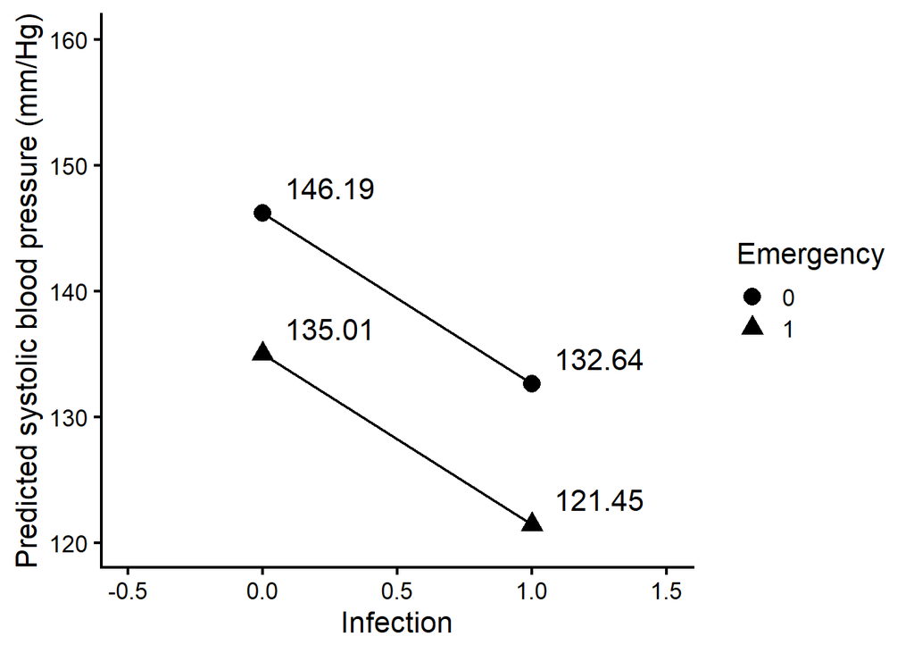

```r
ggplot(data = new_data, aes(x = Infection,
                            y = pred_BP,
                            shape = as.factor(Emergency))) +
  geom_point(size = 4) +
  geom_line() +
  geom_text(aes(label = round(pred_BP, 2)),
            nudge_x = 0.25,
            nudge_y = 2) +
  xlim(-0.5, 1.5) +
  ylim(120, 160) +
  labs(shape = "Emergency",
       y = "Predicted systolic blood pressure (mm/Hg)")
```

- Effect of `Infection`
  - $b_1$ = -13.55
  - Effect of `Infection`, controlling for `Emergency` is the **slope** of the lines
    - When `Emergency` = 0: 132.64 - 146.19 = -13.55
    - When `Emergency` = 1: 121.45 - 135.01 = -13.55
- Effect of `Emergency`
  - $b_2$ = -11.19
  - Effect of `Emergency`, controlling for `Infection` is the **difference** between lines
    - When `Infection` = 0: 135.01 - 146.19 = -11.19
    - When `Infection` = 1: 121.45 - 132.64 = -11.19
5. Using the **predicted** and **residual** values, assess whether the assumptions are met for **model 3**. Include the plots and describe your conclusions based on them.

```r
ICU$pred1 <- fitted(m3)
ICU$resi1 <- residuals(m3)
```

**Note**

- With **caution**, you can use the `warning: false` option to suppress all the warnings that the loess line (`geom_smooth()`) is giving
- `#| warning: false` in the first line of the code chunk
  - Note the `#|` at the start of the line
  - Unfortunately doesn’t show in output, so look at **code**
  - I did this for these first couple of residuals plots because they give warnings because they are trying to calculate a running average at the edges
- Residuals vs predicted value ($\hat{Y}$)
  - Want a flat line with roughly equal variance (vertical spread) across

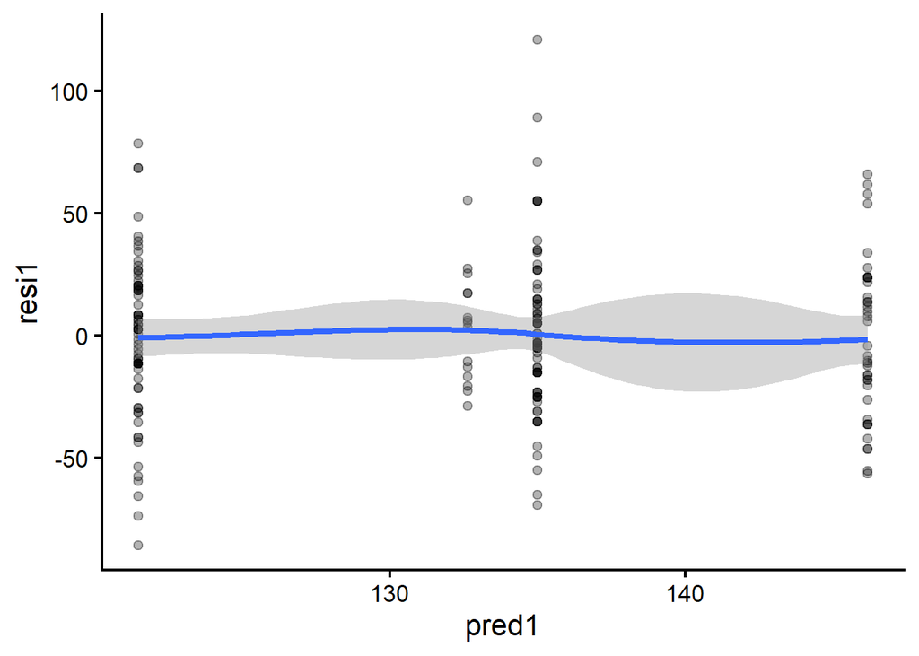

```r
ggplot(data = ICU,
       aes(x = pred1, y = resi1)) +
  geom_point(alpha = 0.3,
             size = 2) +
  geom_smooth()
```

- Residuals vs `Infection`
  - Want a flat line with roughly equal variance (vertical spread) across

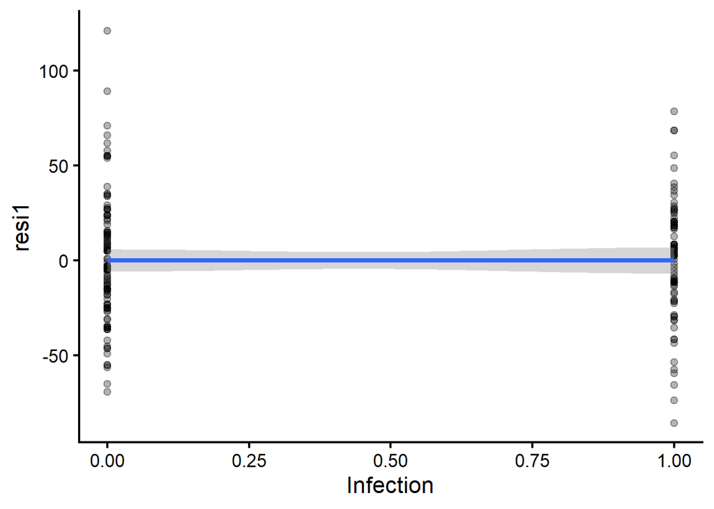

```r
ggplot(data = ICU,
       aes(x = Infection, y = resi1)) +
  geom_point(alpha = 0.3,
             size = 2) +
  geom_smooth()
```

- Residuals vs `Emergency`
  - Want a flat line with roughly equal variance (vertical spread) across

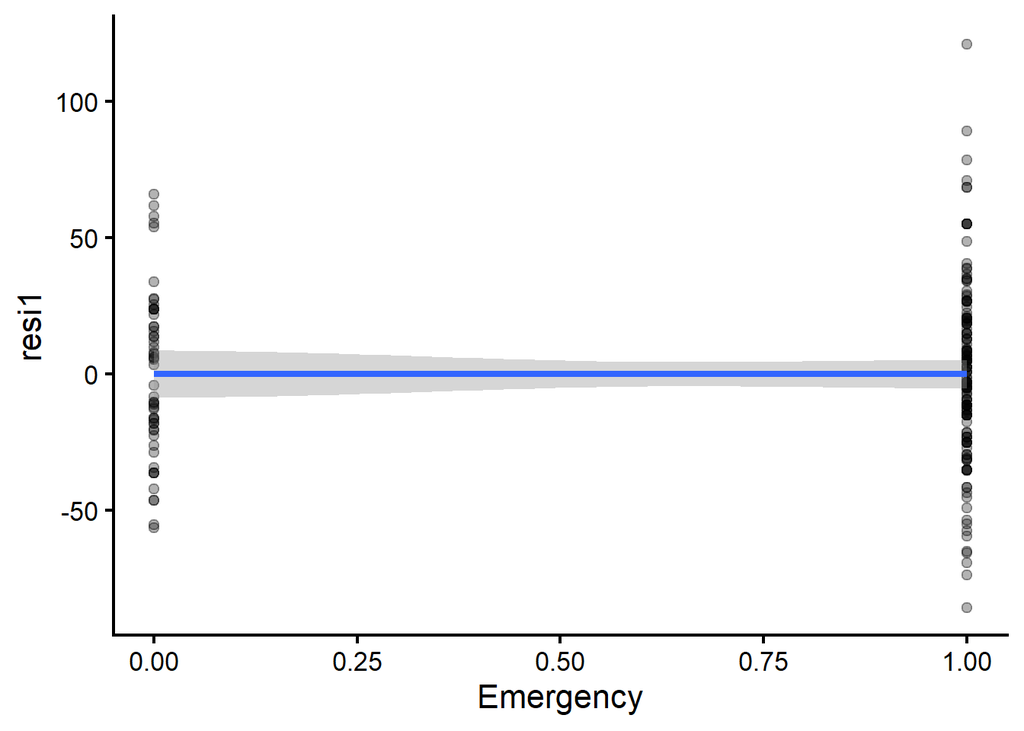

```r
ggplot(data = ICU,
       aes(x = Emergency, y = resi1)) +
  geom_point(alpha = 0.3,
             size = 2) +
  geom_smooth()
```

- Histogram of residuals, conditional on `Infection`
  - Want roughly normal distributions for each

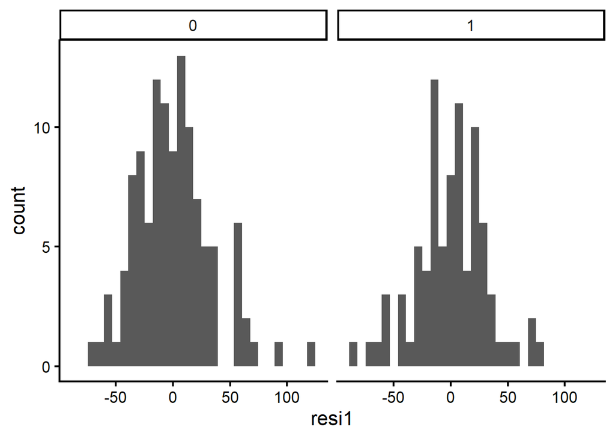

```r
ggplot(data = ICU,
       aes(x = resi1)) +
  geom_histogram() +
  facet_grid(cols = vars(Infection))
```

- Histogram of residuals, conditional on `Emergency`
  - Want roughly normal distributions for each

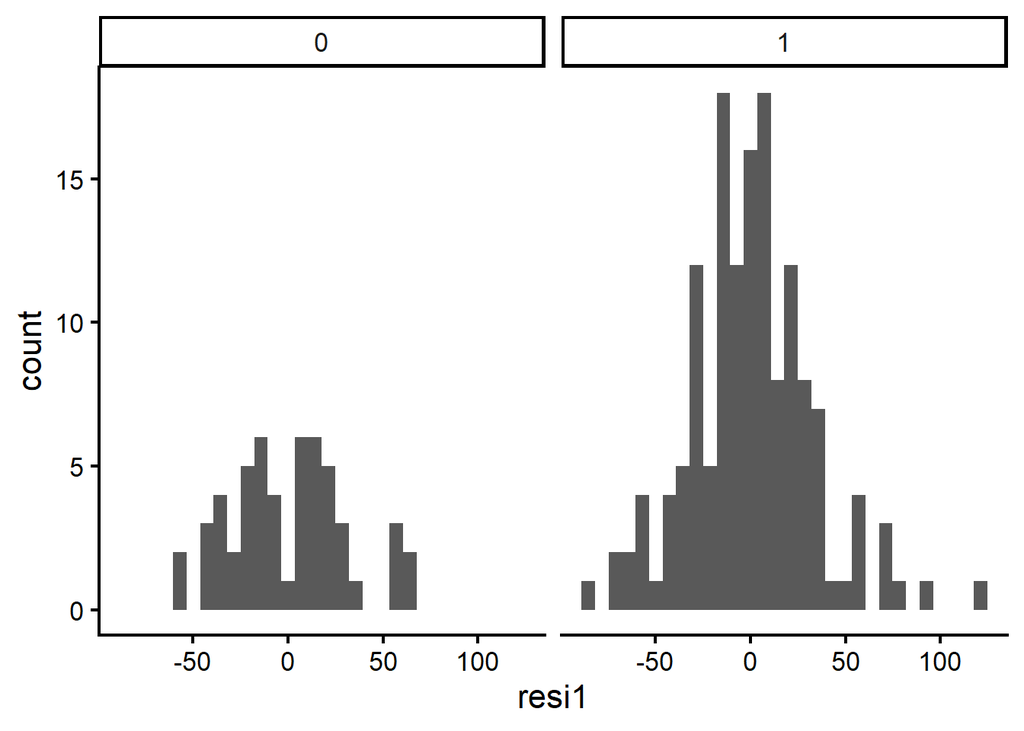

```r
ggplot(data = ICU,
       aes(x = resi1)) +
  geom_histogram() +
  facet_grid(cols = vars(Emergency))
```

6. In plain language, answer the research question: **How do infection status and admission type predict blood pressure?** (This should not be lengthy – just a couple sentences.)
- Whether someone has an infection or not affects blood pressure
  - Patients *with an infection* had **lower** blood pressure than patients *without an infection*
- Whether someone was an emergency admission or not affects blood pressure
  - Patients with *emergency* admissions had **lower** blood pressure than patients with *non-emergency* admissions
- (Note that this model only includes simple **additive** effects, which leads to the parallel lines. What if it instead looked like, e.g., emergency admission doesn’t affect blood pressure for people with infections, but it does for people without infections? **Non-parallel lines**)